# Final Project

Kaitlyn Corey

7/19/2019

## Project Overview

In this project, I will + Import two excell files obtained from a larger [NSDUH data set](https://www.samhsa.gov/data/report/2016-2017-nsduh-state-prevalence-estimates) + Clean up the data frames + Create graphs of both substance use disorder and serious mental illness prevelence by state + Create a scatter plot showing the relationship between substance use disorder prevelence and serious mental illness prevelence by state + Determine correlation + Interpret relationships

## Run Necessary Libraries

Run this part of the code to run the necessary libraries.

```r
library(readxl)
library(dplyr)
library(ggplot2)
```

## Importing Data

Read the excel files provided in the final_project/data folder into the rmarkdown.These files contain the estimated percent of each state population that suffers from 1. substance use disorder and 2. serious mental illness

```r
sub_use <- read_excel("../data/sub_use_perc.xlsx")
srs_mental_ill <- read_excel("../data/srs_mental_ill_perc.xlsx")
```

## Data Frame Manipulation

Edit the sub_use data frame so that 1. unneeded rows (US total, N, S, E, W) are deleted, 2. columns needed are re-named to names without number characters, and 3. only columns that are needed are included (confidence intervals were not included)

```r
sub_use <- sub_use[-c(1,2,3,4,5), ]
names(sub_use)[3]<-"twelve_or_older"
names(sub_use)[6]<-"twelve_to_seventeen"
names(sub_use)[9]<-"eighteen_to_twentyfive"
names(sub_use)[12]<-"twentysix_or_older"
names(sub_use)[15]<-"eighteen_or_older"
sub_use <- select(sub_use, State, twelve_or_older, twelve_to_seventeen, eighteen_to_twentyfive, twentysix_or_older, eighteen_or_older)
print(sub_use)
```

```
## # A tibble: 51 x 6
##    State twelve_or_older twelve_to_seven~ eighteen_to_twe~ twentysix_or_ol~
##    <chr>           <dbl>            <dbl>            <dbl>            <dbl>
##  1 Alab~          0.0659           0.0396            0.121           0.0601
##  2 Alas~          0.0898           0.0654            0.165           0.0804
##  3 Ariz~          0.0745           0.0477            0.160           0.0636
##  4 Arka~          0.0737           0.041             0.136           0.0676
##  5 Cali~          0.0748           0.0463            0.142           0.0669
##  6 Colo~          0.0876           0.056             0.194           0.0739
##  7 Conn~          0.084            0.0464            0.183           0.0722
##  8 Dela~          0.0853           0.0432            0.161           0.0786
##  9 Dist~          0.112            0.0514            0.192           0.100
## 10 Flor~          0.0695           0.0454            0.146           0.0614
## # ... with 41 more rows, and 1 more variable: eighteen_or_older <dbl>
```

Edit the srs_mental_ill data frame so that 1. unneeded rows (US total, N, S, E, W) are deleted, 2. columns needed are re-named to names without number characters, and 3. only columns that are needed are included (confidence intervals not included)

```r
srs_mental_ill <- srs_mental_ill[-c(1,2,3,4,5), ]
names(srs_mental_ill)[3]<-"eighteen_or_older"
names(srs_mental_ill)[6]<-"eighteen_to_twentyfive"
names(srs_mental_ill)[9]<-"twentysix_or_older"
srs_mental_ill <- select(srs_mental_ill, State, eighteen_or_older, eighteen_to_twentyfive, twentysix_or_older)
print(srs_mental_ill)
```

```
## # A tibble: 51 x 4
##    State           eighteen_or_older eighteen_to_twentyf~ twentysix_or_old~
##    <chr>                       <dbl>                <dbl>             <dbl>
##  1 Alabama                    0.048                0.0595            0.0462
##  2 Alaska                     0.0502               0.0853            0.0443
##  3 Arizona                    0.0413               0.0637            0.0376
##  4 Arkansas                   0.0544               0.0665            0.0525
##  5 California                 0.0394               0.0661            0.0348
##  6 Colorado                   0.0508               0.0867            0.0449
##  7 Connecticut                0.0416               0.0743            0.0363
##  8 Delaware                   0.049                0.077             0.0448
##  9 District of Co~            0.0443               0.0625            0.0408
## 10 Florida                    0.0383               0.0641            0.0348
## # ... with 41 more rows
```

## Bar Graphs

Creates a graph showing the estimated percent of individuals with substance use disorder per state, in ascending order of occurance

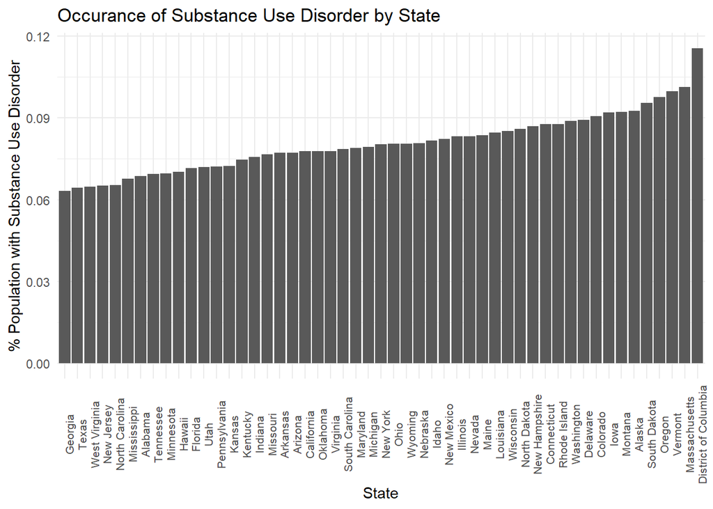

```r
ggplot(data=sub_use) +
  geom_col(aes(x=reorder(State, eighteen_or_older), y=eighteen_or_older)) +
  theme_minimal() +
  theme(axis.text.x = element_text(angle=90, size = 8)) +
  labs(title="Occurance of Substance Use Disorder by State", x="State", y="% Population with Substance Use Disorder")
```

Creates a graph showing the estimated percent of individuals with serious mental disorders per state, in ascending order of occurance

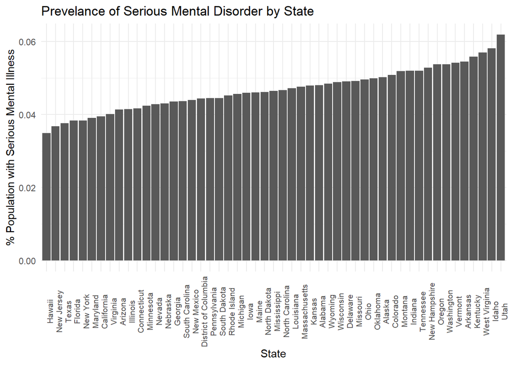

```r
ggplot(data=srs_mental_ill) +
  geom_col(aes(x=reorder(State, eighteen_or_older), y=eighteen_or_older)) +
  theme_minimal() +
  theme(axis.text.x = element_text(angle=90, size = 8)) +
  labs(title="Prevelance of Serious Mental Disorder by State", x= "State", y="% Population with Serious Mental Illness")
```

## Scatterplot

Creates a scatterplot of prevelence of substance use disorder vs prevelence of serious mental illness by state.

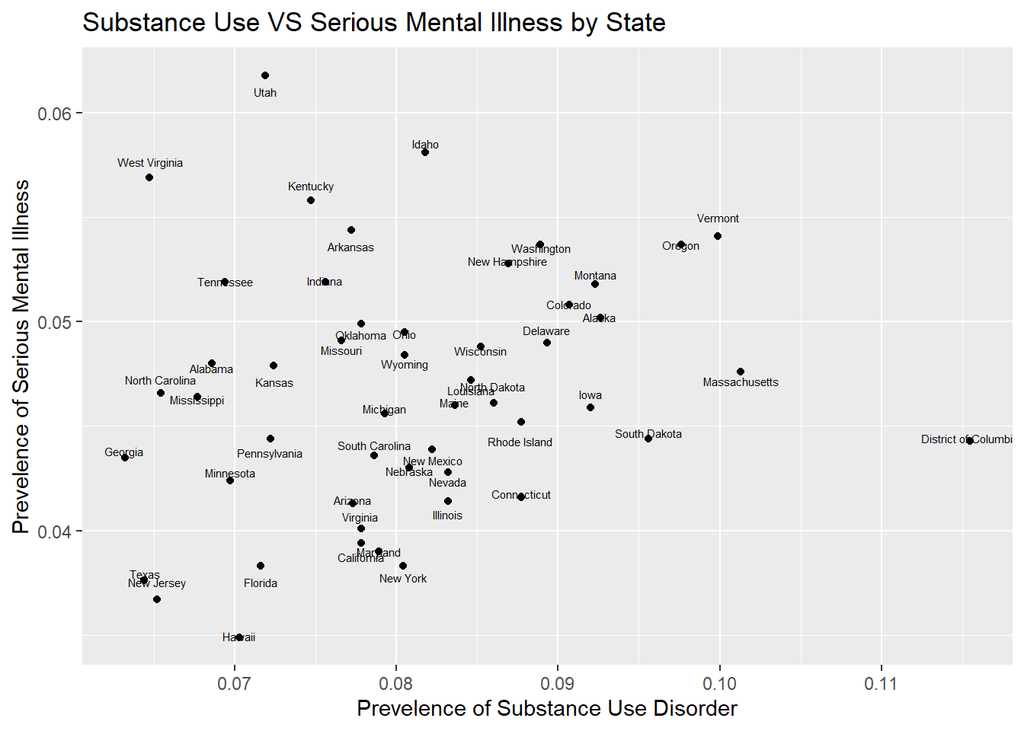

```r
combined <- inner_join(sub_use, srs_mental_ill, by = "State")

ggplot(data=combined) +
  geom_point(aes(x=eighteen_or_older.x, y=eighteen_or_older.y)) +
  geom_text(aes(x=eighteen_or_older.x, y=eighteen_or_older.y, label=State), size = 2, position=position_jitter(height=.001)) +
  labs(title= "Substance Use VS Serious Mental Illness by State", x="Prevelence of Substance Use Disorder", y="Prevelence of Serious Mental Illness")
```

## Correlation Test

This will determine the correlation between occurance of severe mental illness and occurance of substance use disorder through a Pearson Correlation Test. If p < 0.05, the relationship is significant.

```r
cor.test(combined$eighteen_or_older.x, combined$eighteen_or_older.y)
```

```
##
##  Pearson's product-moment correlation
##
## data:  combined$eighteen_or_older.x and combined$eighteen_or_older.y
## t = 1.2507, df = 49, p-value = 0.217
## alternative hypothesis: true correlation is not equal to 0
## 95 percent confidence interval:
##  -0.1047776  0.4305969
## sample estimates:
##       cor
## 0.1758847
```

## Conclusion

Previous research as shown that individuals with serious mental illness many times develop substance use disorder as well (Comer). Based on the bar graphs shown, this does not seem to be the case at a state-by-state level. When plotting the percent of individuals with substance use disorder per state and then the percent of individuals with a serious mental illness per state, one would expect the order of the states along the x axis to be the same (or at least very close) if these true values truly were correlated. However, this is not the case. For example, the state with the highest occurance of serious mental illness was Utah; however, Utah was 12th (from lowest to highest) in terms of substance use disorder.

The next graph created was a scatter plot. I expected to see a positive linear trend; however, this plot does not seem to follow any trend. The points do not seem to illustrate any sort of pattern. Finally, I calculated Pearson’s correlation. To indicate a significant relationship, the p-value would need to be below 0.05. For this data, the p-value was far above 0.05, at 0.217. These figures and this p-value all indicate that, with this data set, there is no significant relationship between the % of the state with a serious mental disorder and % of the state with substance use disorder. Perhaps if other factors were included, such as socioeconomic level, the relationship would become more signifiant. I would be interested to see what SAMHSA consinders to be a serious mental illness. Comer defines “serious mental illness” as bipolar disorder and schizophrenia, as individuals with these disorders often unable to hold a job due to the severe dehibilitation of their illness. For this reason, I believe socioeconomic status may play a role.

## Works cited

Comer, R.J. (2010). Abnormal psychology tenth edition. New York, NY: Worth.